# Simulation-Based Power Analysis

Part 7: Modeling reaction time data — log-normal distribution — Handout

Author

Affiliation

Filip Andras, David López-García & David Sánchez Casasola

Centro de Investigación Mente Cerebro y Comportamiento (CIMCYC), Universidad de Granada

Published

26 May 2026

# 1 The shape of real reaction times

Part 6 left us with a Gaussian-distributed RT that is symmetric and bell-shaped. Real reaction times are not like that. They are **right-skewed**: there is a hard physical lower bound (motor response cannot be faster than ~150-200 ms) and a long tail of slow trials.

A common way to model right-skewed positive data is the **log-normal distribution**: if $\log(\text{RT})$ is normally distributed, then RT itself is log-normal and strictly positive.

This part of the course:

- Compares Gaussian and log-normal models on **real LDT data**.
- Builds a generator that produces log-normal RTs.
- Discusses how to **back-transform** effects from the log scale to the millisecond scale.
- Runs a power analysis and a Type-I error check.

# 2 Real LDT data

Load a real LDT dataset (the same one used in Filip’s PhD work):

```r
library(rio)
dat <- import("../data/raw_data/ldt_data.csv")
head(dat)
```

```
  subject ACC  RT stimuli syl_freq wrd_freq syl_freq.cod wrd_freq.cod
1    S001   0 680  jardin        b        a         -0.5         -0.5
2    S001   0 808   fusil        b        b         -0.5          0.5
3    S001   0 771   sonda        b        b         -0.5          0.5
4    S001   0 772    goma        b        a         -0.5         -0.5
5    S001   0 833   gorra        b        a         -0.5         -0.5
6    S001   0 700    dedo        a        a          0.5         -0.5
```

The dataset has one row per trial, with columns for subject, stimulus, condition (`wrd_freq.cod`), and RT in milliseconds.

# 3 Fitting the model: Gaussian vs log-normal

We compare two models on the same data: one assumes RT is normally distributed, the other models $\log(\text{RT})$. Click between the tabs to compare the model output and the diagnostic panels.

**Gaussian (raw RT)**

```r
m <- lmer(RT ~ wrd_freq.cod + (1 + wrd_freq.cod | subject) + (1 | stimuli),
          data = dat)
summary(m)
```

```
Linear mixed model fit by REML. t-tests use Satterthwaite's method ['lmerModLmerTest']
Formula: RT ~ wrd_freq.cod + (1 + wrd_freq.cod | subject) + (1 | stimuli)
   Data: dat

REML criterion at convergence: 25565.3

Scaled residuals:
    Min      1Q  Median      3Q     Max
-2.6373 -0.6284 -0.1519  0.4275  4.0133

Random effects:
 Groups   Name         Variance Std.Dev. Corr
 stimuli  (Intercept)   2573.7   50.73
 subject  (Intercept)   4232.0   65.05
          wrd_freq.cod   318.7   17.85   0.45
 Residual              19127.0  138.30
Number of obs: 1999, groups:  stimuli, 80; subject, 28

Fixed effects:
             Estimate Std. Error     df t value             Pr(>|t|)
(Intercept)    688.55      13.90  38.06  49.549 < 0.0000000000000002 ***
wrd_freq.cod    76.06      13.39  67.12   5.682          0.000000312 ***
---
Signif. codes:  0 '***' 0.001 '**' 0.01 '*' 0.05 '.' 0.1 ' ' 1

Correlation of Fixed Effects:
            (Intr)
wrd_freq.cd 0.107
```

`performance::check_model()` produces a diagnostic panel for the model assumptions:

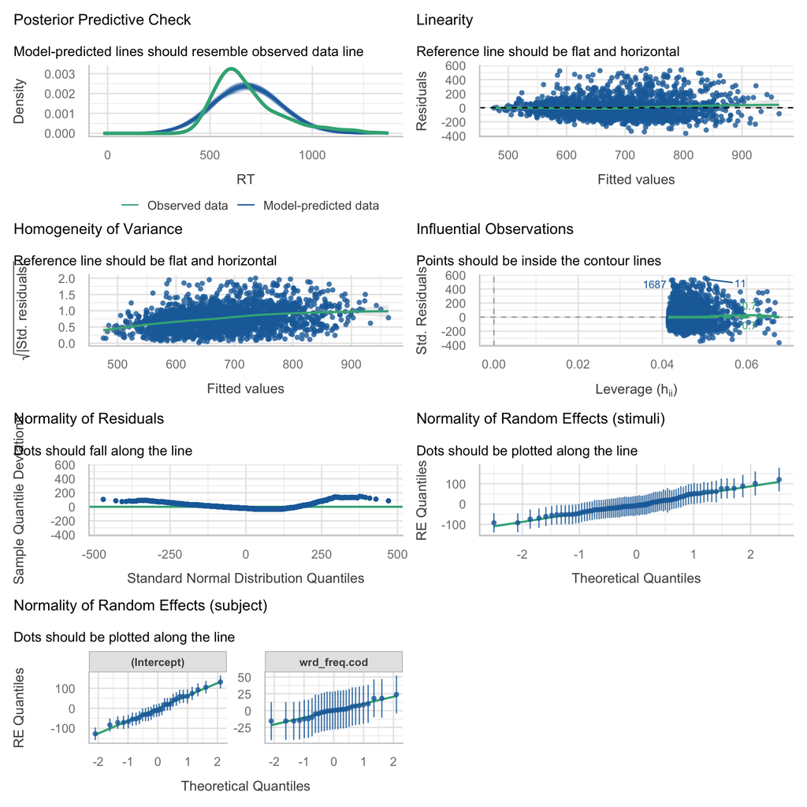

Figure 1: Model diagnostics for RT modeled as Gaussian. Note the strong departure from normality in the QQ plot and the heteroscedasticity in the residuals-vs-fitted plot.

```r
performance::check_model(m)
```

The QQ plot of residuals shows strong departure from normality in the upper tail, and the residuals-vs-fitted plot shows heteroscedasticity (the variance increases with the fitted value). Both are typical signatures of right-skewed data.

**Log-normal (log(RT))**

```r
m_log <- lmer(log(RT) ~ wrd_freq.cod + (1 + wrd_freq.cod | subject) + (1 | stimuli),
              data = dat)
summary(m_log)
```

```
Linear mixed model fit by REML. t-tests use Satterthwaite's method ['lmerModLmerTest']
Formula: log(RT) ~ wrd_freq.cod + (1 + wrd_freq.cod | subject) + (1 |      stimuli)
   Data: dat

REML criterion at convergence: -842.3

Scaled residuals:
    Min      1Q  Median      3Q     Max
-3.1903 -0.6523 -0.0810  0.5459  3.5119

Random effects:
 Groups   Name         Variance  Std.Dev. Corr
 stimuli  (Intercept)  0.0051175 0.07154
 subject  (Intercept)  0.0084441 0.09189
          wrd_freq.cod 0.0004395 0.02096  0.00
 Residual              0.0344230 0.18553
Number of obs: 1999, groups:  stimuli, 80; subject, 28

Fixed effects:
             Estimate Std. Error       df t value             Pr(>|t|)
(Intercept)   6.50802    0.01957 38.13109 332.467 < 0.0000000000000002 ***
wrd_freq.cod  0.10649    0.01849 68.42906   5.759           0.00000022 ***
---
Signif. codes:  0 '***' 0.001 '**' 0.01 '*' 0.05 '.' 0.1 ' ' 1

Correlation of Fixed Effects:
            (Intr)
wrd_freq.cd 0.006
```

Same diagnostic panel for the log-transformed model:

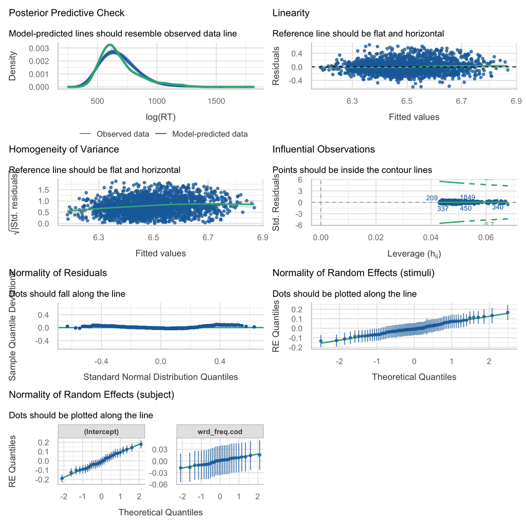

Figure 2: Model diagnostics for log(RT). The QQ plot is much closer to the diagonal and the residual variance is more stable across fitted values.

```r
performance::check_model(m_log)
```

The QQ plot is now much closer to the diagonal and the residual variance is more uniform. This is a substantial improvement.

The log-normal model wins on both diagnostic criteria. From here on the course commits to modelling $\log(\text{RT})$ and the simulation generator switches from `rnorm()` to `rlnorm()`.

# 4 Back to the millisecond scale

Fitting on the log scale costs us interpretability: the coefficients are no longer in milliseconds. To recover ms-scale effects we back-transform with `exp()`.

**Show code (back-transform + 95% CI)**

```r
b0        <- 6.59
b1        <- 0.10
b1_stderr <- 0.02

# point estimate
rt_high <- exp(b0 + b1 * -0.5)
rt_low  <- exp(b0 + b1 *  0.5)
effect  <- rt_low - rt_high

# 95% CI on b1 (log scale), then back-transform
lower <- b1 - 1.96 * b1_stderr
upper <- b1 + 1.96 * b1_stderr

effect_lower <- exp(b0 + lower * 0.5) - exp(b0 + lower * -0.5)
effect_upper <- exp(b0 + upper * 0.5) - exp(b0 + upper * -0.5)

c(rt_high      = rt_high,
  rt_low       = rt_low,
  effect_ms    = effect,
  effect_lower = effect_lower,
  effect_upper = effect_upper)
```

```
     rt_high       rt_low    effect_ms effect_lower effect_upper
   692.28658    765.09499     72.80841     44.25589    101.38891
```

Two takeaways:

- The point estimate is a **~70 ms effect**, but this is conditional on the baseline RT being around 730 ms. The same log-scale effect ($b_1 = 0.10$) implies a different ms-scale effect at different baselines. **This is the most important practical consequence of log-scale modelling.**
- The 95% CI on the ms scale spans roughly **40 to 100 ms** — substantial uncertainty, worth keeping in mind when interpreting the point estimate.

**Tip**

In Bayesian terms, $b_1 \sim \text{Normal}(0.10, 0.02)$. The back-transformed range above corresponds to a 95% credible interval on the ms-scale effect.

# 5 Generating log-normal RTs

To run a power analysis on this model, we need a data generator that produces **log-normal** RTs. The only changes from Part 6’s `gendat_ldt_crossed()`:

- All parameters are now on the **log scale** (so smaller numbers).
- `rnorm()` becomes `rlnorm()` inside the row-by-row loop.

```r
gendat_ldt_crossed_log <- function(n        = 20,    # subjects
                                   k        = 20,    # items per condition
                                   b0       = 6.59,  # log(grand mean RT); exp(6.59) ~ 730 ms
                                   b1       = 0.10,  # log-scale frequency effect (~70 ms on RT scale)
                                   sigma_u0 = 0.2,   # SD of subject intercepts (log)
                                   sigma_u1 = 0.02,  # SD of subject slopes (log)
                                   rho      = -0.5,  # correlation between subject intercepts and slopes
                                   sigma_w  = 0.1,   # SD of item intercepts (log)
                                   sigma    = 0.25) {# residual SD (log)

  # fully crossed design
  sim_dat          <- expand.grid(item = 1:(k * 2), subj = 1:n)
  sim_dat$cond.cod <- rep(c(-0.5, 0.5), each = k)

  # subject random effects (correlated intercepts and slopes)
  Sigma_u <- matrix(c(sigma_u0^2,                  rho * sigma_u0 * sigma_u1,
                      rho * sigma_u0 * sigma_u1,   sigma_u1^2),
                    nrow = 2)
  u <- mvrnorm(n     = length(unique(sim_dat$subj)),
               mu    = c(0, 0),
               Sigma = Sigma_u)

  # item random effects (intercepts only)
  w <- rnorm(n = length(unique(sim_dat$item)), mean = 0, sd = sigma_w)

  # generate RTs row by row -- note rlnorm() instead of rnorm()
  N  <- dim(sim_dat)[1]
  rt <- rep(NA, N)
  for (i in 1:N) {
    rt[i] <- rlnorm(1,
                    b0 +
                    u[sim_dat[i, ]$subj, 1] +
                    w[sim_dat[i, ]$item] +
                    (b1 + u[sim_dat[i, ]$subj, 2]) * sim_dat[i, ]$cond.cod,
                    sigma)
  }

  sim_dat$rt   <- rt
  sim_dat$subj <- factor(sim_dat$subj)
  sim_dat$item <- factor(sim_dat$item)
  sim_dat
}
```

Check that the resulting distribution is right-skewed:

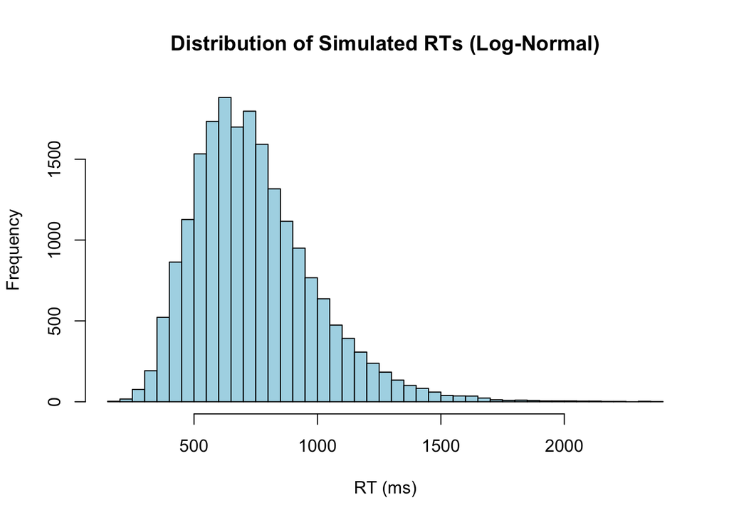

Figure 3: Distribution of simulated RTs from the log-normal generator. The right-skewed shape matches what we see in real RT data.

```r
sim_dat <- gendat_ldt_crossed_log(n = 100, k = 100)
hist(sim_dat$rt,
     main = "Distribution of Simulated RTs (Log-Normal)",
     xlab = "RT (ms)", col = "lightblue", breaks = 50)
```

Compare with the Gaussian histogram from Part 6 — the log-normal version has the characteristic right tail and a hard zero lower bound.

# 6 Sanity check on the log-normal model

Fit the same log(rt) model on simulated data to confirm the generator and the model agree:

```r
sim_dat <- gendat_ldt_crossed_log(n = 20, k = 20)

m <- lmer(log(rt) ~ cond.cod + (1 + cond.cod | subj) + (1 | item), sim_dat,
          control = lmerControl(calc.derivs = FALSE))
summary(m)
```

```
Linear mixed model fit by REML. t-tests use Satterthwaite's method ['lmerModLmerTest']
Formula: log(rt) ~ cond.cod + (1 + cond.cod | subj) + (1 | item)
   Data: sim_dat
Control: lmerControl(calc.derivs = FALSE)

REML criterion at convergence: 210.8

Scaled residuals:
    Min      1Q  Median      3Q     Max
-3.2457 -0.6307  0.0385  0.6571  2.5831

Random effects:
 Groups   Name        Variance  Std.Dev. Corr
 item     (Intercept) 0.0128846 0.1135
 subj     (Intercept) 0.0396077 0.1990
          cond.cod    0.0008236 0.0287   0.36
 Residual             0.0642270 0.2534
Number of obs: 800, groups:  item, 40; subj, 20

Fixed effects:
            Estimate Std. Error       df t value            Pr(>|t|)
(Intercept)  6.58998    0.04881 24.92877 135.003 <0.0000000000000002 ***
cond.cod     0.08963    0.04063 36.22206   2.206              0.0338 *
---
Signif. codes:  0 '***' 0.001 '**' 0.01 '*' 0.05 '.' 0.1 ' ' 1

Correlation of Fixed Effects:
         (Intr)
cond.cod 0.052
```

The fixed-effect estimates should be close to the generating values (6.59 and 0.10).

# 7 Power analysis

With the log-normal generator in hand, the power loop is identical in shape to the previous parts — only the simulator and model formula change:

```r
nsim  <- 1000
pvals <- rep(NA, nsim)

for (i in 1:nsim) {
  sim_dat <- gendat_ldt_crossed_log(n = 20, k = 20,
                                    b0 = 6.59, b1 = 0.10,
                                    sigma_u0 = 0.2, sigma_u1 = 0.02,
                                    rho = -0.5, sigma_w = 0.1, sigma = 0.25)

  m <- lmer(log(rt) ~ cond.cod + (1 + cond.cod | subj) + (1 | item), sim_dat,
            control = lmerControl(calc.derivs = FALSE))
  pvals[i] <- summary(m)$coefficients[2, 5]
}

power <- round(mean(pvals < 0.05), digits = 4)
power
```

```
[1] 0.751
```

# 8 Parameter recovery (seven parameters now)

```r
nsim   <- 1000
params <- matrix(rep(NA, nsim * 7), ncol = 7)

for (i in 1:nsim) {
  sim_dat <- gendat_ldt_crossed_log(n = 20, k = 20,
                                    b0 = 6.59, b1 = 0.10,
                                    sigma_u0 = 0.2, sigma_u1 = 0.02,
                                    rho = -0.5, sigma_w = 0.1, sigma = 0.25)
  m <- lmer(log(rt) ~ cond.cod + (1 + cond.cod | subj) + (1 | item), sim_dat,
            control = lmerControl(calc.derivs = FALSE))

  params[i, 1] <- summary(m)$coefficients[1, 1] # b0
  params[i, 2] <- summary(m)$coefficients[2, 1] # b1
  params[i, 3] <- attr(VarCorr(m), "sc")        # residual SD
  vc           <- as.data.frame(VarCorr(m))
  params[i, 4] <- vc$sdcor[1]                   # SD item intercepts
  params[i, 5] <- vc$sdcor[2]                   # SD subject slopes
  params[i, 6] <- vc$sdcor[3]                   # SD subject intercepts
  params[i, 7] <- vc$sdcor[4]                   # rho (subj intercept-slope correlation)
}
```

[figure not shown]

Figure 4: Parameter recovery for the log-normal model with n = 20, k = 20, 1000 simulations. Red lines mark the true generating values.

The fixed effects and large variance components recover cleanly. The correlation $\rho$ is still the noisiest parameter, as we saw in Part 5.

# 9 Type-I error check

A useful sanity check on any new generative process: when the true effect is **zero**, what proportion of simulations falsely declare significance? The answer should be approximately $\alpha = 0.05$.

```r
nsim  <- 1000
pvals <- rep(NA, nsim)

for (i in 1:nsim) {
  sim_dat <- gendat_ldt_crossed_log(n = 20, k = 20,
                                    b0 = 6.59, b1 = 0,         # NO EFFECT
                                    sigma_u0 = 0.2, sigma_u1 = 0.0, # no slope variability
                                    rho = 0.0, sigma_w = 0.1, sigma = 0.25)

  m <- lmer(log(rt) ~ cond.cod + (1 + cond.cod | subj) + (1 | item), sim_dat,
            control = lmerControl(calc.derivs = FALSE))
  pvals[i] <- summary(m)$coefficients[2, 5]
}

type1_error <- mean(pvals < 0.05)
type1_error
```

```
[1] 0.046
```

If the value is close to 0.05, the model and the generative process are consistent. Substantially higher would suggest the inference is anti- conservative; substantially lower, the model is conservative.

# 10 Summary and next step

In this part we:

- Recognised that real RTs are right-skewed and not well-described by a Gaussian.
- Fit `log(RT)` instead of `RT` to obtain better-behaved residuals.
- Walked through the back-transformation from log(ms) to ms and showed that the ms-scale effect depends on the baseline RT.
- Built `gendat_ldt_crossed_log()` to simulate from a log-normal generative process.
- Verified power, parameter recovery, and the Type-I error rate.

**Tip**

For an interactive comparison of RT distributions (log-normal, ex-Gaussian, shifted log-normal, etc.), see Jonas K. Lindeløv’s [shiny app](https://lindeloev.shinyapps.io/shiny-rt/).

The final form of the data-generating process is:

$$\log(rt_{ij}) = \beta_0 + u_{0i} + w_{0j} + (\beta_1 + u_{1i}) \times \text{cond.cod}_{ij} + \varepsilon_{ij}$$

The next (final) part of the course **iterates the power analysis across a grid of sample sizes and effect sizes**, with confidence intervals on each estimate. This is the standard deliverable for a sample-size justification in a research proposal or pre-registration.